# Flexible Damage Functions

Author

James Rising, Sebastian Cadavid Sanchez, Climate Impact Lab

Published

April 30, 2026

## 0.1 Energy: Electricity Country

Flexible damage function parameters at the Country level.

**Outcome units:** `kWh_per_capita` — kWh per capita for electricity, rebased to 2005 baseline; pre-aggregated to country in projection system

$$D_{it} = (\alpha_i T_t + \beta_i T_t^2) \cdot Y_{it}^{\gamma}$$

where $\gamma$ is the income elasticity (fitted globally), $\alpha_i$ is the linear coefficient, and $\beta_i$ is the quadratic coefficient.

# 1 Global Estimation

## 1.1 Income Elasticity Estimation

The income elasticity $\gamma$ is estimated using a fixed-effects regression:

$$y_{it} = \gamma \cdot \log(Y_{it}) + \mu_{g(i,T)} + \nu_t + \varepsilon_{it}$$

where $\mu_{g(i,T)}$ are region-by-temperature-bin fixed effects and $\nu_t$ are year fixed effects.

Table 1: Income Elasticity (Gamma) Estimation Results

| Statistic | Value |
| --- | --- |
| Income elasticity ($\gamma$) | 0.3586 |
| Standard error | 3.14e-02 |
| 95% CI | [0.2971, 0.4201] |
| R-squared | 0.8462 |
| Observations | 3,519,180 |
| Regions | 245 |
| Gamma quantiles | 19 |

# 2 Parameter Distributions

## 2.1 8-Panel Summary

Row 1: gamma, alpha, beta, rsqr1. Row 2: rho, zeta, eta, rsqr2.

```
Using median gamma: 0.358586, 245 rows (of 4,655 total)
```

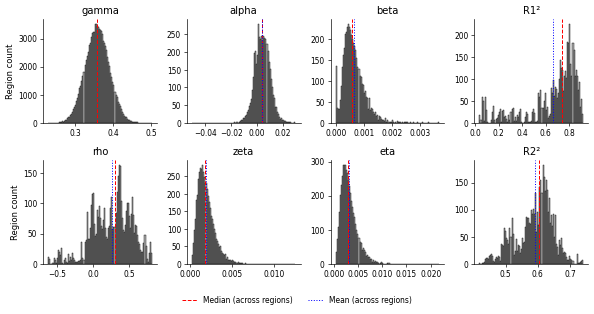

Figure 1: Distribution of Regional Parameters

## 2.2 Projection Equation and Parameter Definitions

The estimated parameters are used to project damages via Monte Carlo sampling:

$$D_{it}^k = (\hat{\alpha}_{ik} T_t + \hat{\beta}_{ik} T_t^2) Y_{it}^{\hat{\gamma}_k} + \hat{\theta}_{ik} T_t Y_{it}^{\hat{\gamma}_k} + \hat{\phi}_{it}^k$$

where $k$ indexes the Monte Carlo draw. The parameters in each row of the output CSV control distinct components of this equation:

- **gamma**: income elasticity $\hat{\gamma}_k$, one of 19 quantile values drawn from $N(\hat{\gamma}, SE(\hat{\gamma}))$
- **alpha, beta**: linear and quadratic temperature coefficients; $\hat{\alpha}_{ik}$ and $\hat{\beta}_{ik}$ are drawn from the joint normal defined by the VCV below
- **sigma11, sigma12, sigma22**: variance-covariance matrix of $(\alpha, \beta)$, used for joint uncertainty sampling
- **rho**: correlation between regional and global polynomial residuals $\rho_i$, used to maintain spatial covariance across regions in Monte Carlo draws
- **zeta**: temperature-dependent error scale $\zeta_{ik}$; the run-specific error term $\hat{\theta}_{ik}$ is drawn from $N(0, \zeta_{ik})$
- **eta**: residual noise standard deviation $\eta_{ik}$; the annual noise $\hat{\phi}_{it}^k$ is drawn from $N(0, \eta_{ik})$
- **rsqr1, rsqr2**: polynomial fit quality and error model fit, respectively

## 2.3 Summary Statistics

Table 2: Regional Parameter Summary

| Parameter | Mean | Median | Std | Min | Max | N |
| --- | --- | --- | --- | --- | --- | --- |
| alpha | 0.003876 | 0.004054 | 0.005756 | -0.0298 | 0.01605 | 245 |
| beta | 0.0006062 | 0.0005845 | 0.0002938 | 0 | 0.002268 | 245 |
| rho | 0.2596 | 0.3008 | 0.2788 | -0.6112 | 0.796 | 245 |
| zeta | 0.00182 | 0.001805 | 0.0008447 | 0.0003307 | 0.007193 | 245 |
| eta | 0.003021 | 0.002828 | 0.001391 | 0.0006312 | 0.01265 | 245 |
| rsqr1 | 0.6617 | 0.7411 | 0.2249 | 0.03911 | 0.9129 | 245 |
| rsqr2 | 0.5916 | 0.6044 | 0.05672 | 0.4379 | 0.7352 | 245 |

# 3 Spaghetti Curves

Regional damage function curves showing D(T) = αT + βT² for sampled regions.

[interactive chart not shown]

Figure 2: Regional Damage Functions

# 4 Zero Crossings

The zero crossing (extremum) of the parabola occurs at $T^* = -\alpha / (2\beta)$.

Table 3: Zero Crossing Statistics

| Category | Count | Percentage |
| --- | --- | --- |
| β = 0 (no crossing) | 6 | 2.4% |
| T > 20°C (beyond graph) | 0 | 0.0% |
| T < 0°C (negative crossing) | 182 | 74.3% |
| Valid crossings (0-20°C) | 57 | 23.3% |

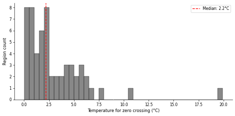

Figure 3: Distribution of Zero Crossing Temperatures

# 5 Slope Analysis

Maximum slope between 0 and 10°C: $\frac{dM}{dT} = \alpha + 2\beta T$

The maximum occurs at either T=0 or T=10 (endpoints of interval).

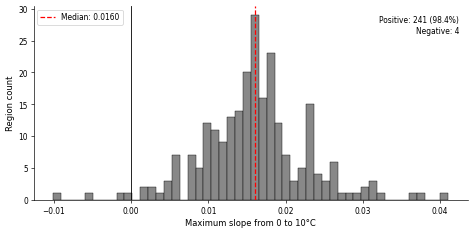

Figure 4: Distribution of Maximum Slopes (0-10°C)

*Convexity analysis omitted (beta constraint active).*

# 6 R-squared Analysis

## 6.1 Polynomial Fit Quality (rsqr1)

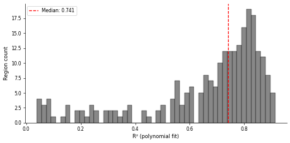

Figure 5: Regional Fit Quality (R-squared)

## 6.2 Error Model R-squared (rsqr2) Quantiles

Table 4: rsqr2 Quantiles

| 0% (Min) | 25% | 50% (Median) | 75% | 100% (Max) |
| --- | --- | --- | --- | --- |
| 0.4379 | 0.5617 | 0.6044 | 0.6294 | 0.7352 |

# 7 Modelled Variance

Modelled variance statistic: $1 - \frac{\sum_i \eta_i^2}{\sum_i D_i^2}$

Table 5: Modelled Variance Statistics

| Statistic | Value |
| --- | --- |
| Modelled variance | 0.9805 |
| Sum(η²) | 0.0027 |
| Sum(D²) at T=3.0°C | 0.1391 |
| N regions | 245 |

# 8 Best- and Worst-Fitting Regions

The 3 worst- and 3 best-fitting regions by R-squared, with raw simulation data overlaid on the fitted polynomial curve. **Red rows = worst fits**, **green rows = best fits**.

Table 6: Best- and worst-fitting regions

Top 3 best fit (R²) Top 3 worst fit (R²)

| Region | α | β | η | R² |
| --- | --- | --- | --- | --- |
| BRA | 0.00866 | 7.07e-4 | 0.00238 | 0.913 |
| MEX | 0.00654 | 4.69e-4 | 0.00176 | 0.908 |
| MYS | 0.0116 | 3.87e-4 | 0.00283 | 0.905 |
| LSO | -0.00271 | 6.25e-4 | 0.00278 | 0.0391 |
| CZE | -0.00329 | 6.59e-4 | 0.00302 | 0.0524 |
| SVK | -0.00344 | 6.97e-4 | 0.0031 | 0.054 |

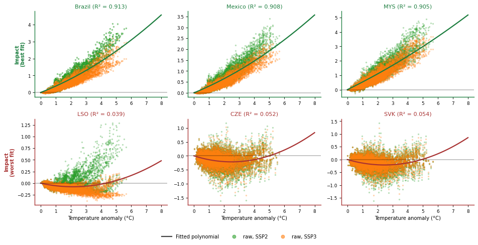

# 9 Regional Parameter Maps

## 9.1 Alpha (Linear Coefficient)

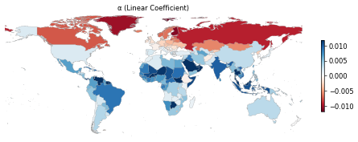

Figure 7: α (linear coefficient)

## 9.2 Beta (Quadratic Coefficient)

Beta ($\beta$) represents the curvature of the damage function.

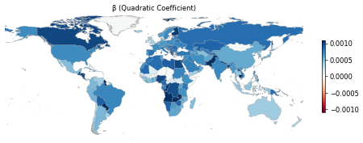

Figure 8: β (quadratic coefficient)

## 9.3 R-squared (Fit Quality)

$R^2$ measures the polynomial fit quality. Higher values indicate that the quadratic form captures more of the variance in the data.

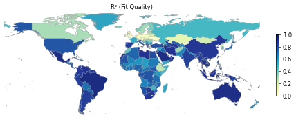

Figure 9: R² (stage 1 fit quality)

# 10 F2: Flex vs Raw Comparison

Comparison of flexible damage function predictions against raw simulation means.

For each scenario (RCP × SSP × Model), we compute at the final year:

- **Flex predicted**: $(\alpha \cdot T + \beta \cdot T^2) \cdot Y^\gamma$
- **Raw actual**: The outcome variable (y) from the source data

**Year 2099**: 65,780 rows

**rcp45**

**SSP2**

**high**

**Correlation:** 0.9657 | **RMSE:** 0.262874 | **Sign agreement:** 95.5%

[interactive chart not shown]

Top 5 best predicted Top 5 worst predicted

Year 2099 · T<sub>mean</sub> across these regions: 1.96°C

| Region | Raw | Flex | Residual |
| --- | --- | --- | --- |
| ARE | 2.43 | 2.43 | 7.86e-5 |
| PLW | 1.1 | 1.1 | -0.00114 |
| FLK | -0.194 | -0.195 | -0.00145 |
| GUM | 1.16 | 1.16 | 0.00252 |
| PCN | 0.169 | 0.166 | -0.00321 |
| PAK | 1.21 | 0.468 | -0.741 |
| ZMB | 1.12 | 0.4 | -0.72 |
| SDN | 1.66 | 1.01 | -0.648 |
| NIC | 1.41 | 0.764 | -0.648 |
| MRT | 1.61 | 0.973 | -0.641 |

**low**

**Correlation:** 0.9825 | **RMSE:** 0.142642 | **Sign agreement:** 95.9%

[interactive chart not shown]

Top 5 best predicted Top 5 worst predicted

Year 2099 · T<sub>mean</sub> across these regions: 1.96°C

| Region | Raw | Flex | Residual |
| --- | --- | --- | --- |
| ARE | 2.43 | 2.43 | 7.86e-5 |
| PRI | 1.03 | 1.03 | 0.00272 |
| SEN | 0.537 | 0.534 | -0.00331 |
| MNP | 0.949 | 0.945 | -0.00364 |
| CIV | 0.633 | 0.629 | -0.00375 |
| AGO | 0.849 | 0.33 | -0.519 |
| ABW | 1.04 | 0.548 | -0.495 |
| PAK | 0.857 | 0.388 | -0.468 |
| KHM | 1.3 | 0.861 | -0.434 |
| IRQ | 1.5 | 1.07 | -0.424 |

**SSP3**

**high**

**Correlation:** 0.9880 | **RMSE:** 0.087578 | **Sign agreement:** 96.3%

[interactive chart not shown]

Top 5 best predicted Top 5 worst predicted

Year 2099 · T<sub>mean</sub> across these regions: 1.96°C

| Region | Raw | Flex | Residual |
| --- | --- | --- | --- |
| KNA | 0.751 | 0.751 | 1.28e-5 |
| MTQ | 0.749 | 0.749 | -3.78e-4 |
| MSR | 0.75 | 0.751 | 4.61e-4 |
| GLP | 0.752 | 0.753 | 9.48e-4 |
| USA | 0.373 | 0.372 | -0.00118 |
| SJM | -1.68 | -2.06 | -0.383 |
| IRQ | 0.368 | 0.64 | 0.272 |
| PRY | 0.903 | 0.644 | -0.259 |
| BRN | 1.59 | 1.34 | -0.254 |
| NIC | 0.718 | 0.509 | -0.209 |

**low**

**Correlation:** 0.9799 | **RMSE:** 0.106544 | **Sign agreement:** 96.3%

[interactive chart not shown]

Top 5 best predicted Top 5 worst predicted

Year 2099 · T<sub>mean</sub> across these regions: 1.96°C

| Region | Raw | Flex | Residual |
| --- | --- | --- | --- |
| ERI | 0.16 | 0.16 | 2.65e-5 |
| ZWE | 0.0645 | 0.0643 | -1.97e-4 |
| USA | 0.406 | 0.405 | -9.62e-4 |
| BDI | 0.0432 | 0.0443 | 0.0011 |
| JAM | 0.874 | 0.873 | -0.00118 |
| SJM | -0.907 | -1.8 | -0.894 |
| MNG | 0.11 | -0.302 | -0.412 |
| GRL | -0.422 | -0.735 | -0.314 |
| SSD | 0.918 | 1.15 | 0.233 |
| SYR | 0.0208 | 0.241 | 0.22 |

**rcp85**

**SSP2**

**high**

**Correlation:** 0.9672 | **RMSE:** 0.638887 | **Sign agreement:** 96.7%

[interactive chart not shown]

Top 5 best predicted Top 5 worst predicted

Year 2099 · T<sub>mean</sub> across these regions: 4.20°C

| Region | Raw | Flex | Residual |
| --- | --- | --- | --- |
| FRO | -0.393 | -0.385 | 0.00746 |
| FLK | -0.422 | -0.395 | 0.0273 |
| ISL | -1.42 | -1.36 | 0.0553 |
| JAM | 2.25 | 2.19 | -0.057 |
| HKG | 3.17 | 3.11 | -0.0593 |
| SDN | 4.31 | 2.52 | -1.8 |
| TCD | 3.78 | 2.11 | -1.67 |
| BFA | 4.03 | 2.47 | -1.56 |
| MLI | 3.65 | 2.09 | -1.56 |
| DJI | 4.13 | 2.64 | -1.49 |

**low**

**Correlation:** 0.9823 | **RMSE:** 0.335655 | **Sign agreement:** 96.7%

[interactive chart not shown]

Top 5 best predicted Top 5 worst predicted

Year 2099 · T<sub>mean</sub> across these regions: 4.20°C

| Region | Raw | Flex | Residual |
| --- | --- | --- | --- |
| CCK | 1.1 | 1.09 | -0.00836 |
| GUF | 2.57 | 2.58 | 0.0101 |
| FLK | -0.325 | -0.339 | -0.0136 |
| THA | 3.62 | 3.64 | 0.0231 |
| FRO | -0.307 | -0.33 | -0.0234 |
| IRQ | 3.99 | 2.68 | -1.31 |
| AGO | 2.3 | 1.22 | -1.08 |
| SDN | 3.01 | 2.03 | -0.978 |
| YEM | 2.33 | 1.46 | -0.875 |
| PAK | 2.19 | 1.38 | -0.814 |

**SSP3**

**high**

**Correlation:** 0.9846 | **RMSE:** 0.227621 | **Sign agreement:** 95.9%

[interactive chart not shown]

Top 5 best predicted Top 5 worst predicted

Year 2099 · T<sub>mean</sub> across these regions: 4.20°C

| Region | Raw | Flex | Residual |
| --- | --- | --- | --- |
| GRD | 1.92 | 1.92 | -6.47e-5 |
| CYM | 2.11 | 2.11 | -0.00136 |
| WLF | 1.48 | 1.47 | -0.00169 |
| SRB | 0.51 | 0.508 | -0.00226 |
| MTQ | 1.77 | 1.77 | 0.00427 |
| SJM | -2.74 | -3.54 | -0.791 |
| KWT | 5.8 | 5.04 | -0.754 |
| IRQ | 0.948 | 1.6 | 0.65 |
| BRN | 3.89 | 3.27 | -0.62 |
| PRY | 2.53 | 1.93 | -0.607 |

**low**

**Correlation:** 0.9706 | **RMSE:** 0.267380 | **Sign agreement:** 96.3%

[interactive chart not shown]

Top 5 best predicted Top 5 worst predicted

Year 2099 · T<sub>mean</sub> across these regions: 4.20°C

| Region | Raw | Flex | Residual |
| --- | --- | --- | --- |
| CMR | 0.769 | 0.768 | -4.47e-4 |
| VUT | 1.18 | 1.18 | 0.00285 |
| URY | 0.78 | 0.777 | -0.00324 |
| COD | 0.786 | 0.777 | -0.00892 |
| LCA | 1.92 | 1.91 | -0.00966 |
| SJM | -1.48 | -3.09 | -1.61 |
| MNG | 0.25 | -0.649 | -0.899 |
| GRL | -0.861 | -1.58 | -0.718 |
| LUX | 0.934 | 0.264 | -0.671 |
| PRY | 0.682 | 1.33 | 0.647 |

## 10.1 Scenario Summary

| RCP | SSP | Model | N | Corr | RMSE | Sign% |
| --- | --- | --- | --- | --- | --- | --- |
| rcp45 | SSP2 | high | 245 | 0.9657 | 0.262874 | 95.5% |
| rcp45 | SSP2 | low | 245 | 0.9825 | 0.142642 | 95.9% |
| rcp45 | SSP3 | high | 245 | 0.988 | 0.087578 | 96.3% |
| rcp45 | SSP3 | low | 245 | 0.9799 | 0.106544 | 96.3% |
| rcp85 | SSP2 | high | 245 | 0.9672 | 0.638887 | 96.7% |
| rcp85 | SSP2 | low | 245 | 0.9823 | 0.335655 | 96.7% |
| rcp85 | SSP3 | high | 245 | 0.9846 | 0.227621 | 95.9% |
| rcp85 | SSP3 | low | 245 | 0.9706 | 0.26738 | 96.3% |

# 11 Data Reference

## 11.1 File Locations

| Item | Path |
| --- | --- |
| Regional CSV | `/project/cil/gcp/flex_damage_funcs/parameters/energy__electricity_country__regional_parameters.csv` |
| Global JSON | `/project/cil/gcp/flex_damage_funcs/parameters/energy__electricity_country__global_results.json` |
| Metadata JSON | `/project/cil/gcp/flex_damage_funcs/parameters/energy__electricity_country__metadata.json` |

## 11.2 Column Definitions

| Column | Description |
| --- | --- |
| `region` | Region identifier (hierarchical code, first 3 chars = country ISO3) |
| `gamma` | Income elasticity quantile value |
| `alpha` | Linear temperature coefficient |
| `beta` | Quadratic temperature coefficient |
| `sigma11` | Var(alpha) |
| `sigma12` | Cov(alpha, beta) |
| `sigma22` | Var(beta) |
| `rho` | Correlation with global residual process |
| `zeta` | Temperature-dependent heteroskedasticity |
| `eta` | Residual standard deviation |
| `rsqr1` | R-squared of polynomial fit |
| `rsqr2` | R-squared of error model |

*Report generated with FlexDamage v1.0.0*